# Boston_DescriptiveStatistics

Roxana Butenco

18 June 2019

In this document we’ll look at the dataset in more detail and will seek significant predictors in relation to crime. Will look at the correlation between all variables to analyse each correlation coefficient, getting a first impression of the relationship between them. At the moment the goal is to find what kind of regression modelling, if any, can be applied to data for better crime prediction (for example if linear trends are visible, we may apply a linear regression model).

Specify the working directory and read in data from a csv file:

```r
setwd("~/RDemo/BostonRegression")
Boston = read.csv(file="Boston.csv",header=TRUE,sep=",")
#library(MASS)
#attach(Boston)
data("Boston")
#View(Boston) #invoke the data viewer that also contain some basic exploratory features
#fix(Boston) #open a quick data editor
#??Boston #get familliar with the dataset from its original source
```

Descriptive Statistics

```r
library(pastecs)
library(DescTools)
stat.desc(Boston)
```

```
##                      crim          zn        indus         chas
## nbr.val       506.0000000  506.000000  506.0000000 506.00000000
## nbr.null        0.0000000  372.000000    0.0000000 471.00000000
## nbr.na          0.0000000    0.000000    0.0000000   0.00000000
## min             0.0063200    0.000000    0.4600000   0.00000000
## max            88.9761963  100.000000   27.7399998   1.00000000
## range          88.9698763  100.000000   27.2799998   1.00000000
## sum          1828.4429218 5750.000000 5635.2100473  35.00000000
## median          0.2565100    0.000000    9.6899996   0.00000000
## mean            3.6135236   11.363636   11.1367787   0.06916996
## SE.mean         0.3823853    1.036810    0.3049799   0.01129141
## CI.mean.0.95    0.7512620    2.036991    0.5991856   0.02218393
## var            73.9865779  543.936814   47.0644430   0.06451297
## std.dev         8.6015451   23.322453    6.8603530   0.25399404
## coef.var        2.3803761    2.052376    0.6160087   3.67202814
##                       nox           rm          age          dis
## nbr.val      5.060000e+02 5.060000e+02 5.060000e+02 5.060000e+02
## nbr.null     0.000000e+00 0.000000e+00 0.000000e+00 0.000000e+00
## nbr.na       0.000000e+00 0.000000e+00 0.000000e+00 0.000000e+00
## min          3.850000e-01 3.561000e+00 2.900000e+00 1.129600e+00
## max          8.710000e-01 8.780000e+00 1.000000e+02 1.212650e+01
## range        4.860000e-01 5.219000e+00 9.710000e+01 1.099690e+01
## sum          2.806757e+02 3.180025e+03 3.469890e+04 1.920292e+03
## median       5.380000e-01 6.208500e+00 7.750000e+01 3.207450e+00
## mean         5.546951e-01 6.284634e+00 6.857490e+01 3.795043e+00
## SE.mean      5.151391e-03 3.123514e-02 1.251370e+00 9.361023e-02
## CI.mean.0.95 1.012080e-02 6.136683e-02 2.458531e+00 1.839135e-01
## var          1.342764e-02 4.936709e-01 7.923584e+02 4.434015e+00
## std.dev      1.158777e-01 7.026172e-01 2.814886e+01 2.105710e+00
## coef.var     2.089034e-01 1.117992e-01 4.104834e-01 5.548581e-01
##                       rad          tax      ptratio        black
## nbr.val       506.0000000 5.060000e+02 5.060000e+02 5.060000e+02
## nbr.null        0.0000000 0.000000e+00 0.000000e+00 0.000000e+00
## nbr.na          0.0000000 0.000000e+00 0.000000e+00 0.000000e+00
## min             1.0000000 1.870000e+02 1.260000e+01 3.200000e-01
## max            24.0000000 7.110000e+02 2.200000e+01 3.969000e+02
## range          23.0000000 5.240000e+02 9.400000e+00 3.965800e+02
## sum          4832.0000000 2.065680e+05 9.338500e+03 1.804771e+05
## median          5.0000000 3.300000e+02 1.905000e+01 3.914400e+02
## mean            9.5494071 4.082372e+02 1.845553e+01 3.566740e+02
## SE.mean         0.3870849 7.492389e+00 9.624358e-02 4.058552e+00
## CI.mean.0.95    0.7604951 1.472009e+01 1.890871e-01 7.973726e+00
## var            75.8163660 2.840476e+04 4.686990e+00 8.334752e+03
## std.dev         8.7072594 1.685371e+02 2.164946e+00 9.129486e+01
## coef.var        0.9118115 4.128412e-01 1.173061e-01 2.559616e-01
##                     lstat         medv
## nbr.val       506.0000000 5.060000e+02
## nbr.null        0.0000000 0.000000e+00
## nbr.na          0.0000000 0.000000e+00
## min             1.7300000 5.000000e+00
## max            37.9700012 5.000000e+01
## range          36.2400012 4.500000e+01
## sum          6402.4499964 1.140160e+04
## median         11.3600001 2.120000e+01
## mean           12.6530632 2.253281e+01
## SE.mean         0.3174589 4.088611e-01
## CI.mean.0.95    0.6237028 8.032783e-01
## var            50.9947593 8.458672e+01
## std.dev         7.1410615 9.197104e+00
## coef.var        0.5643741 4.081651e-01
```

```r
str(Boston)
```

```
## 'data.frame':    506 obs. of  14 variables:
##  $ crim   : num  0.00632 0.02731 0.02729 0.03237 0.06905 ...
##  $ zn     : num  18 0 0 0 0 0 12.5 12.5 12.5 12.5 ...
##  $ indus  : num  2.31 7.07 7.07 2.18 2.18 ...
##  $ chas   : int  0 0 0 0 0 0 0 0 0 0 ...
##  $ nox    : num  0.538 0.469 0.469 0.458 0.458 ...
##  $ rm     : num  6.57 6.42 7.18 7 7.15 ...
##  $ age    : num  65.2 78.9 61.1 45.8 54.2 ...
##  $ dis    : num  4.09 4.97 4.97 6.06 6.06 ...
##  $ rad    : int  1 2 2 3 3 3 5 5 5 5 ...
##  $ tax    : int  296 242 242 222 222 222 311 311 311 311 ...
##  $ ptratio: num  15.3 17.8 17.8 18.7 18.7 ...
##  $ black  : num  397 397 393 395 397 ...
##  $ lstat  : num  4.98 9.14 4.03 2.94 5.33 ...
##  $ medv   : num  24 21.6 34.7 33.4 36.2 ...
```

```r
cat("\nThe mean : ", mean(Boston$crim))
```

```
##
## The mean :  3.613524
```

```r
cat("\nThe median : ", median(Boston$crim))
```

```
##
## The median :  0.25651
```

```r
cat("\nThe mode : ", mode(Boston$crim))
```

```
##
## The mode :  numeric
```

```r
cat("\nThe standard deviation : ", sd(Boston$crim), "\n")
```

```
##
## The standard deviation :  8.601545
```

```r
#library(data.table)
library(Hmisc)
describe(Boston)
```

```
## Boston
##
##  14  Variables      506  Observations
## ---------------------------------------------------------------------------
## crim
##        n  missing distinct     Info     Mean      Gmd      .05      .10
##      506        0      504        1    3.614    5.794  0.02791  0.03820
##      .25      .50      .75      .90      .95
##  0.08205  0.25651  3.67708 10.75300 15.78915
##
## lowest :  0.00632  0.00906  0.01096  0.01301  0.01311
## highest: 45.74610 51.13580 67.92080 73.53410 88.97620
## ---------------------------------------------------------------------------
## zn
##        n  missing distinct     Info     Mean      Gmd      .05      .10
##      506        0       26    0.603    11.36    18.77      0.0      0.0
##      .25      .50      .75      .90      .95
##      0.0      0.0     12.5     42.5     80.0
##
## lowest :   0.0  12.5  17.5  18.0  20.0, highest:  82.5  85.0  90.0  95.0 100.0
## ---------------------------------------------------------------------------
## indus
##        n  missing distinct     Info     Mean      Gmd      .05      .10
##      506        0       76    0.982    11.14    7.705     2.18     2.91
##      .25      .50      .75      .90      .95
##     5.19     9.69    18.10    19.58    21.89
##
## lowest :  0.46  0.74  1.21  1.22  1.25, highest: 18.10 19.58 21.89 25.65 27.74
## ---------------------------------------------------------------------------
## chas
##        n  missing distinct     Info      Sum     Mean      Gmd
##      506        0        2    0.193       35  0.06917    0.129
##
## ---------------------------------------------------------------------------
## nox
##        n  missing distinct     Info     Mean      Gmd      .05      .10
##      506        0       81        1   0.5547   0.1295   0.4093   0.4270
##      .25      .50      .75      .90      .95
##   0.4490   0.5380   0.6240   0.7130   0.7400
##
```

[output cut: 60 more lines]

```
##        n  missing distinct     Info     Mean      Gmd      .05      .10
##      506        0      455        1    12.65    7.881    3.708    4.680
##      .25      .50      .75      .90      .95
##    6.950   11.360   16.955   23.035   26.807
##
## lowest :  1.73  1.92  1.98  2.47  2.87, highest: 34.37 34.41 34.77 36.98 37.97
## ---------------------------------------------------------------------------
## medv
##        n  missing distinct     Info     Mean      Gmd      .05      .10
##      506        0      229        1    22.53    9.778    10.20    12.75
##      .25      .50      .75      .90      .95
##    17.03    21.20    25.00    34.80    43.40
##
## lowest :  5.0  5.6  6.3  7.0  7.2, highest: 46.7 48.3 48.5 48.8 50.0
## ---------------------------------------------------------------------------
```

```r
describe(~ Boston$crim+Boston$zn)
```

```
## Boston$crim + Boston$zn
##
##  2  Variables      506  Observations
## ---------------------------------------------------------------------------
## Boston$crim
##        n  missing distinct     Info     Mean      Gmd      .05      .10
##      506        0      504        1    3.614    5.794  0.02791  0.03820
##      .25      .50      .75      .90      .95
##  0.08205  0.25651  3.67708 10.75300 15.78915
##
## lowest :  0.00632  0.00906  0.01096  0.01301  0.01311
## highest: 45.74610 51.13580 67.92080 73.53410 88.97620
## ---------------------------------------------------------------------------
## Boston$zn
##        n  missing distinct     Info     Mean      Gmd      .05      .10
##      506        0       26    0.603    11.36    18.77      0.0      0.0
##      .25      .50      .75      .90      .95
##      0.0      0.0     12.5     42.5     80.0
##
## lowest :   0.0  12.5  17.5  18.0  20.0, highest:  82.5  85.0  90.0  95.0 100.0
## ---------------------------------------------------------------------------
```

```r
deff(Boston$crim, Boston$zn)
```

```
##            n     clusters          rho         deff
## 5.060000e+02 2.600000e+01 8.320373e-03 3.287741e+00
```

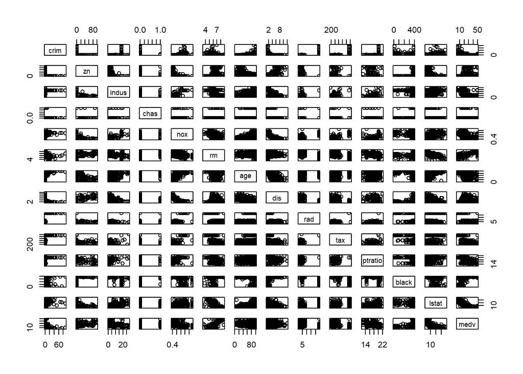

```r
plot(Boston)
```

Install and load some required packages

```r
#install.packages("pastecs")
#install.packages("corrr")
#install.packages("gridExtra")
#install.packages("ggplot2")
#install.packages("tidyverse")
#install.packages("dplyr")
#install.packages("DT")
#install.packages("leaps")
#install.packages("glmnet")
#install.packages("PerformanceAnalytics")
#install.packages("DescTools")

library(corrr)
library(gridExtra)
library(ggplot2)
library(tidyverse)
library(dplyr)
library(DT)
library(leaps)
library(glmnet)
library(PerformanceAnalytics)
```

```r
Boston %>% correlate() %>% focus(crim)
```

```
##
## Correlation method: 'pearson'
## Missing treated using: 'pairwise.complete.obs'
```

```
## # A tibble: 13 x 2
##    rowname    crim
##    <chr>     <dbl>
##  1 zn      -0.200
##  2 indus    0.407
##  3 chas    -0.0559
##  4 nox      0.421
##  5 rm      -0.219
##  6 age      0.353
##  7 dis     -0.380
##  8 rad      0.626
##  9 tax      0.583
## 10 ptratio  0.290
## 11 black   -0.385
## 12 lstat    0.456
## 13 medv    -0.388
```

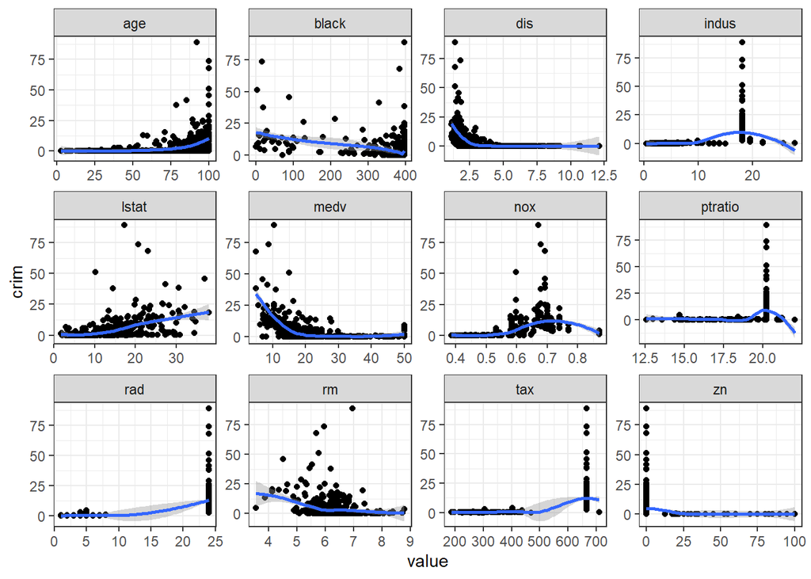

```r
Boston %>%
  gather(-crim, key = "var", value = "value") %>%
  filter(var != "chas") %>%
  ggplot(aes(x = value, y = crim)) +
  geom_point() +
  stat_smooth() +
  facet_wrap(~ var, scales = "free") +
  theme_bw()
```

Correlation matrix visualization with Pearson correlation coefficient Predictor variables correlation chart

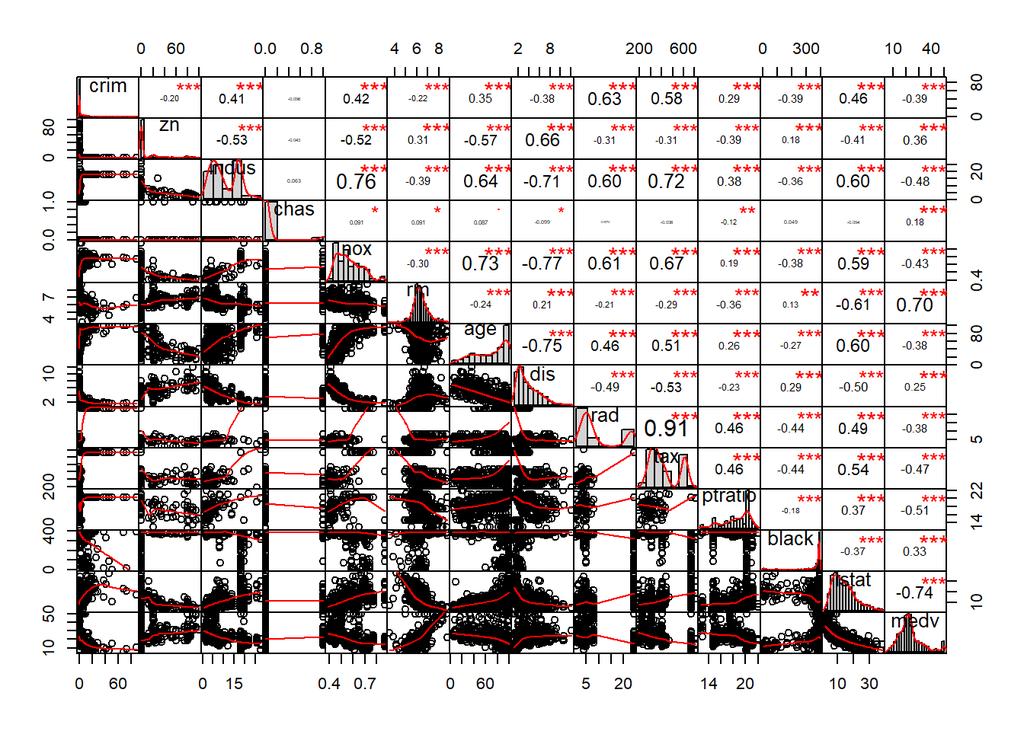

```r
chart.Correlation(Boston, histogram=TRUE, pch=19)
```

Correlation matrix visualization with Pearson correlation coefficient

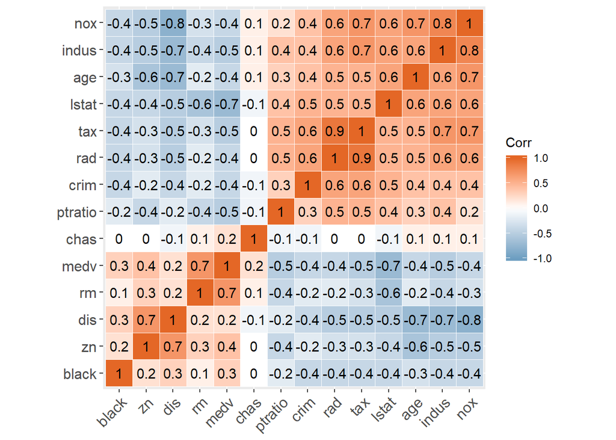

```r
#install.packages("ggcorrplot")
#if(!require(devtools)) install.packages("devtools")
#devtools::install_github("kassambara/ggcorrplot")
library(ggcorrplot)
library(ggplot2)
corr <- round(cor(Boston), 1)
ggcorrplot(corr, lab=TRUE, hc.order = TRUE, outline.col = "white", type = "full", ggtheme = ggplot2::theme_gray,
           colors = c("#6D9EC1", "white", "#E46726"))
```

Boxplots and a closer look at crim and zn and:

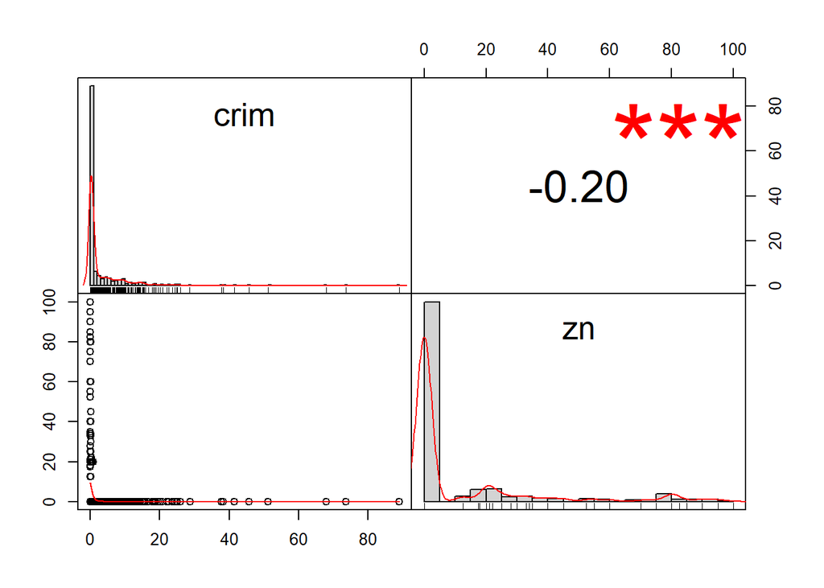

```r
my_data <- Boston[, c(1,2)]
chart.Correlation(my_data, histogram=TRUE, pch=19)
```